# Lista de Exercícios 1

Thaís Paiva

19/03/2018

## Comandos Básicos no R

### Exercício 1

O objeto `data.table` herda as funcionalidade de um objeto `data.frame`, mas oferece acesso mais rápido e mais eficiente. A diferença principal é a maneira de acessar os objetos. Com um objeto `data.table`, é possível realizar uma operação do tipo:

`DT[i, j, by]`

que significa pegar a tabela `DT`, selecionar as linhas `i`, e computar `j` agrupado por `by`. Esse mesmo comando exigiria uma sintaxe mais complexa ao trabalhar com objetos do tipo `data.frame`.

### Exercício 2

É possível imprimir o valor de log(4) com o comando abaixo:

```r
print( log(4), digits = 15)
```

```
## [1] 1.38629436111989
```

### Exercício 3

A função `intersect` encontra a interseção entre dois vetores, ou seja, os elementos que estão em ambos.

```r
seq(4,28,by=7)
```

```
## [1]  4 11 18 25
```

```r
seq(3,31,by=2)
```

```
##  [1]  3  5  7  9 11 13 15 17 19 21 23 25 27 29 31
```

```r
intersect( seq(4,28,by=7), seq(3,31,by=2) )
```

```
## [1] 11 25
```

### Exercício 4

O comando abaixo irá fazer a operação **E** elemento a elemento dos dois vetores de tamanho quatro. Como os vetores são da classe `logical`, o resultado da operação será `TRUE` se ambos os elementos forem `TRUE`, e `FALSE` caso contrário.

```r
c(TRUE,TRUE,FALSE,FALSE) & c(TRUE,FALSE,FALSE,TRUE)
```

```
## [1]  TRUE FALSE FALSE FALSE
```

## Importando Dados

### Exercício 5

Primeiro, vamos carregar a base de dados completa.

```r
file = "../../datasets/extremedatasince1899.csv"
StormMax = read.table(file, header=T, sep=",")
head(StormMax, 3)
```

```
##     Yr Region     Wmax   nao   soi        sst      sstmda sun split
## 1 1899  Basin 96.64138 -0.64 -0.21 0.05193367 -0.03133333 8.4     0
## 2 1899   East 90.19791 -0.64 -0.21 0.05193367 -0.03133333 8.4     0
## 3 1899  Basin 90.35300 -0.64 -0.21 0.05193367 -0.03133333 8.4     0
```

Agora podemos selecionar os eventos que ocorreram apenas no século XX. São 1782 dados de ciclones que ocorreram entre os anos 1900 e 2000.

```r
sec20 = subset(StormMax, subset=StormMax$Yr>1900 & StormMax$Yr<=2000)
dim(sec20)
```

```
## [1] 1782    9
```

### Exercício 6

Para ordernar os dados em ordem crescente da velocidade do vento (variável `Wmax`), podemos executar o seguinte comando:

```r
sec20 = sec20[ order(sec20$Wmax),]
head(sec20)
```

```
##        Yr  Region     Wmax    nao        soi         sst     sstmda   sun
## 1553 1987    East 10.00000 -0.695 -1.1633333  0.30893367 0.29500000  33.9
## 1559 1987      US 10.00000 -0.695 -1.1633333  0.30893367 0.29500000  33.9
## 1541 1986 Florida 10.01247  0.435 -0.2800000 -0.13673300 0.06766667   3.8
## 1618 1990    East 15.00000 -0.385 -0.5533333  0.24493367 0.28233333 125.2
## 1078 1960    Gulf 15.00052 -0.170  0.3266667  0.33193367 0.05566667 127.2
## 1678 1994    East 15.00240  0.780 -1.7700000  0.01293367 0.12233333  25.7
##      split
## 1553     1
## 1559     1
## 1541     1
## 1618     1
## 1078     1
## 1678     1
```

```r
tail(sec20)
```

```
##        Yr Region     Wmax    nao        soi          sst      sstmda   sun
## 877  1950  Basin 160.8074 -0.235  1.1500000  0.004600333 -0.09100000  51.3
## 1585 1988  Basin 160.8934 -1.995  1.5433333  0.047933667  0.09000000 120.1
## 1438 1980  Basin 165.0000 -1.230 -0.3133333  0.093267000  0.01533333 155.0
## 1226 1969  Basin 171.3285 -0.700 -1.0533333 -0.055399667  0.04400000  91.3
## 1236 1969   Gulf 171.3285 -0.700 -1.0533333 -0.055399667  0.04400000  91.3
## 1239 1969     US 171.3285 -0.700 -1.0533333 -0.055399667  0.04400000  91.3
##      split
## 877      1
## 1585     1
## 1438     1
## 1226     1
## 1236     1
## 1239     1
```

### Exercício 7

```r
media = mean(sec20$Wmax[sec20$Region=="Basin"])
```

A média da velocidade do vento `Wmax` na região `Basin` é 74.9437991.

### Exercício 8

O gráfico de dispersão entre o ano e a velocidade do vento pode ser gerado com os comandos abaixo. Adicionamos também uma linha com a regressão ajustada estre as duas variáveis. Notamos que não há nenhuma tendência de crescimento ou decrescimento da velociadade ao longo do século XX.

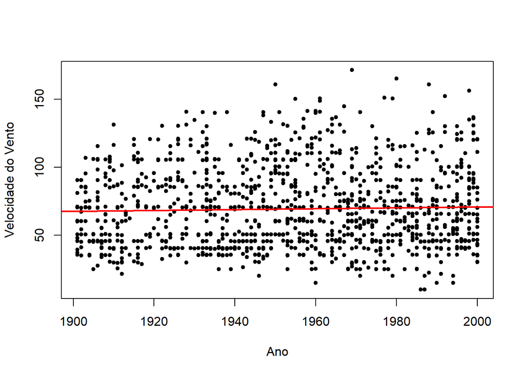

```r
plot(sec20$Yr, sec20$Wmax, pch=20, xlab="Ano", ylab="Velocidade do Vento")
abline(lm(sec20$Wmax ~ sec20$Yr), col=2, lwd=2)
```

O gráfico também poderia ser gerado usando o pacote `ggplot2`, que facilita a inclusão de uma linha de tendência suavizada.

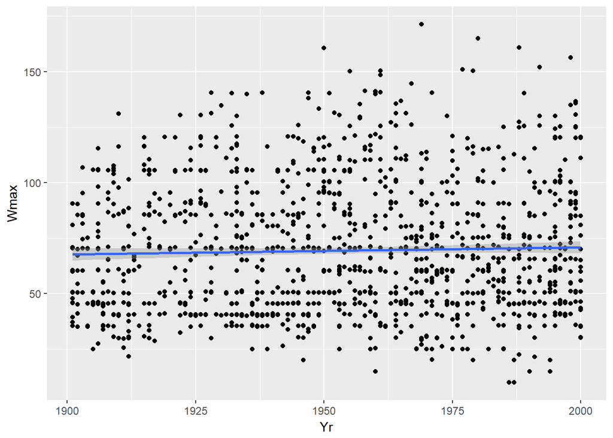

```r
library(ggplot2)
ggplot(sec20, aes(Yr,Wmax)) + geom_point() + geom_smooth(method="lm")
```